# DATA624 HW5

Exponential Smoothing

Betsy Rosalen

3/8/2020

## Exercise 7.1

Consider the `pigs` series — the number of pigs slaughtered in Victoria each month.

### a. Use the `ses()` function in R to find the optimal values of $\alpha$ and $\ell_0$, and generate forecasts for the next four months.

```r
pigs <- fma::pigs
tail(pigs)
```

```
##         Mar    Apr    May    Jun    Jul    Aug
## 1995 106723  84307 114896 106749  87892 100506
```

```r
fcpigs <- ses(pigs, h=4)
summary(fcpigs)
```

```
##
## Forecast method: Simple exponential smoothing
##
## Model Information:
## Simple exponential smoothing
##
## Call:
##  ses(y = pigs, h = 4)
##
##   Smoothing parameters:
##     alpha = 0.2971
##
##   Initial states:
##     l = 77260.0561
##
##   sigma:  10308.58
##
##      AIC     AICc      BIC
## 4462.955 4463.086 4472.665
##
## Error measures:
##                    ME    RMSE      MAE       MPE     MAPE      MASE       ACF1
## Training set 385.8721 10253.6 7961.383 -0.922652 9.274016 0.7966249 0.01282239
##
## Forecasts:
##          Point Forecast    Lo 80    Hi 80    Lo 95    Hi 95
## Sep 1995       98816.41 85605.43 112027.4 78611.97 119020.8
## Oct 1995       98816.41 85034.52 112598.3 77738.83 119894.0
## Nov 1995       98816.41 84486.34 113146.5 76900.46 120732.4
## Dec 1995       98816.41 83958.37 113674.4 76092.99 121539.8
```

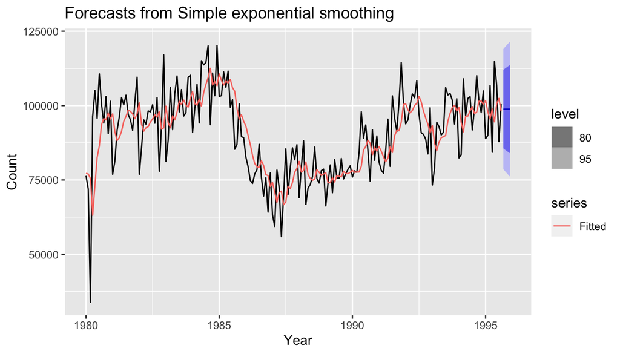

```r
autoplot(fcpigs) +
  autolayer(fcpigs$fitted, series="Fitted") +
  ylab("Count") + xlab("Year")
```

### b. Compute a 95% prediction interval for the first forecast using $\hat{y} \pm 1.96s$ where $s$ is the standard deviation of the residuals. Compare your interval with the interval produced by R.

```r
s <- sd(fcpigs$residuals)
fcpigs$mean[1] - 1.96 * s
```

```
## [1] 78679.97
```

```r
fcpigs$mean[1] + 1.96 * s
```

```
## [1] 118952.8
```

The manually calculated interval is a little narrower than the one calculated by R.

## Exercise 7.5

Data set `books` contains the daily sales of paperback and hardcover books at the same store. The task is to forecast the next four days’ sales for paperback and hardcover books.

### a. Plot the series and discuss the main features of the data.

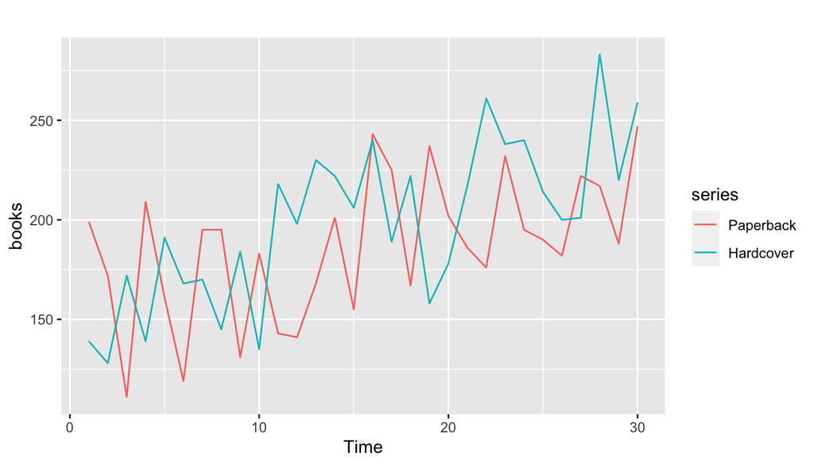

```r
books <- fma::books
autoplot(books)
```

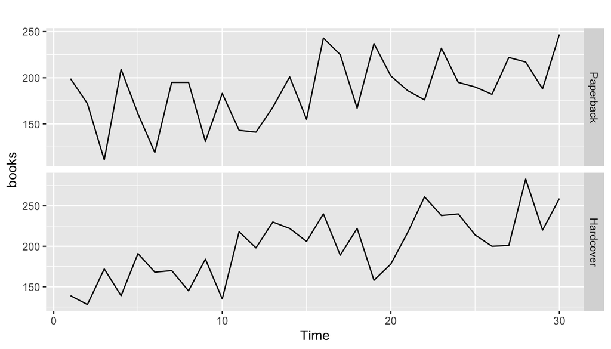

```r
autoplot(books, facets=TRUE)
```

```r
head(books)
```

```
## Time Series:
## Start = 1
## End = 6
## Frequency = 1
##   Paperback Hardcover
## 1       199       139
## 2       172       128
## 3       111       172
## 4       209       139
## 5       161       191
## 6       119       168
```

```r
tail(books)
```

```
## Time Series:
## Start = 25
## End = 30
## Frequency = 1
##    Paperback Hardcover
## 25       190       214
## 26       182       200
## 27       222       201
## 28       217       283
## 29       188       220
## 30       247       259
```

[figure not shown]

```r
gglagplot(books)
```

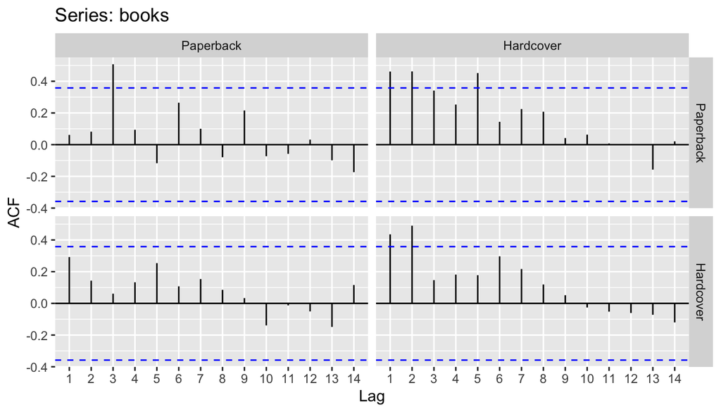

```r
ggAcf(books, lag.max = 14)
```

We only have 30 days worth of data, so it’s hard to know if there might be any annual or monthly seasonality. If there is any weekly seasonality it’s difficult to see within that period. There does seem to be a pattern in the ACF plots though with almost all of the lags being positive.

Let’s convert the series to weekly seasonality and try plotting again and decomposition.

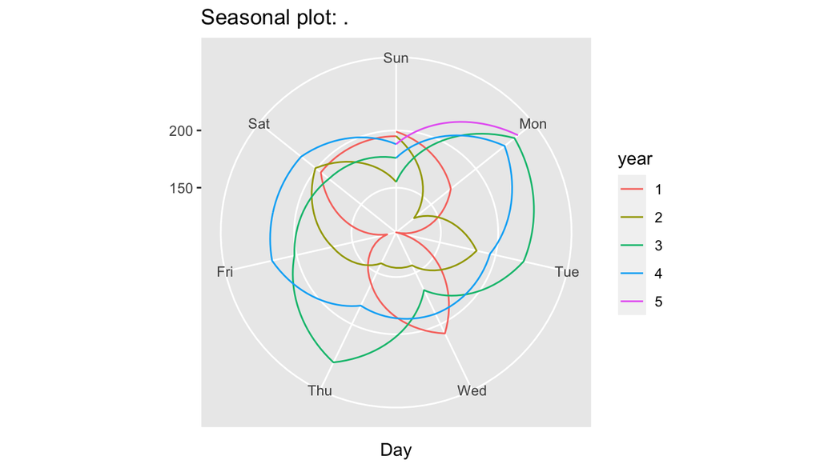

```r
paperback <- books[,"Paperback"] %>% ts(frequency = 7)
paperback %>% ggseasonplot(polar = TRUE)
```

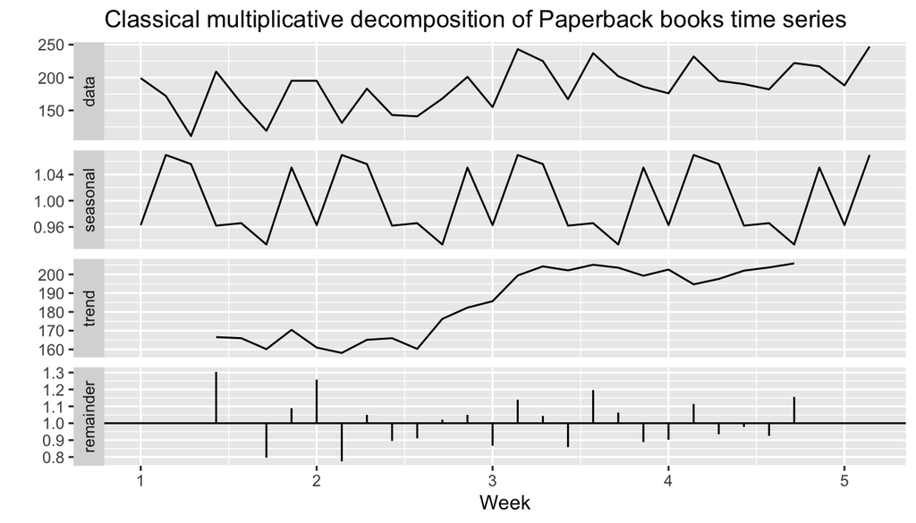

```r
paperback %>% decompose(type="multiplicative") %>%
  autoplot() + xlab("Week") +
  ggtitle("Classical multiplicative decomposition of Paperback books time series")
```

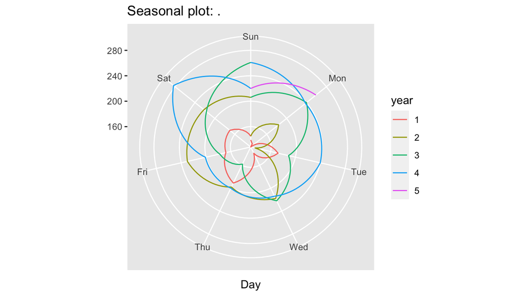

```r
hardcover <- books[,"Hardcover"] %>% ts(frequency = 7)
hardcover %>% ggseasonplot(polar = TRUE)
```

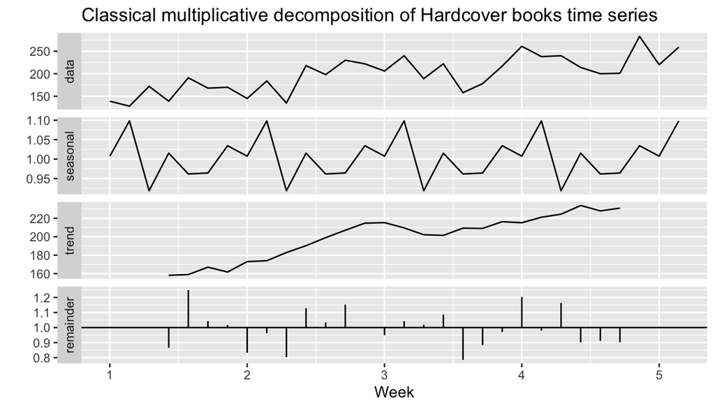

```r
hardcover %>% decompose(type="multiplicative") %>%
  autoplot() + xlab("Week") +
  ggtitle("Classical multiplicative decomposition of Hardcover books time series")
```

The decompositions make it look like there is weekly seasonality in both paperback and hardcover book sales, but looking at the polar seasonal plots it’s hard to see that being true.

### b. Use the `ses()` function to forecast each series, and plot the forecasts.

```r
sesPaperback <- ses(paperback, h=4)
summary(sesPaperback)
```

```
##
## Forecast method: Simple exponential smoothing
##
## Model Information:
## Simple exponential smoothing
##
## Call:
##  ses(y = paperback, h = 4)
##
##   Smoothing parameters:
##     alpha = 0.1685
##
##   Initial states:
##     l = 170.8271
##
##   sigma:  34.8183
##
##      AIC     AICc      BIC
## 318.9747 319.8978 323.1783
##
## Error measures:
##                    ME     RMSE     MAE       MPE     MAPE      MASE       ACF1
## Training set 7.175981 33.63769 27.8431 0.4736071 15.57784 0.7632792 -0.2117522
##
## Forecasts:
##          Point Forecast    Lo 80    Hi 80    Lo 95    Hi 95
## 5.285714       207.1097 162.4882 251.7311 138.8670 275.3523
## 5.428571       207.1097 161.8589 252.3604 137.9046 276.3147
## 5.571429       207.1097 161.2382 252.9811 136.9554 277.2639
## 5.714286       207.1097 160.6259 253.5935 136.0188 278.2005
```

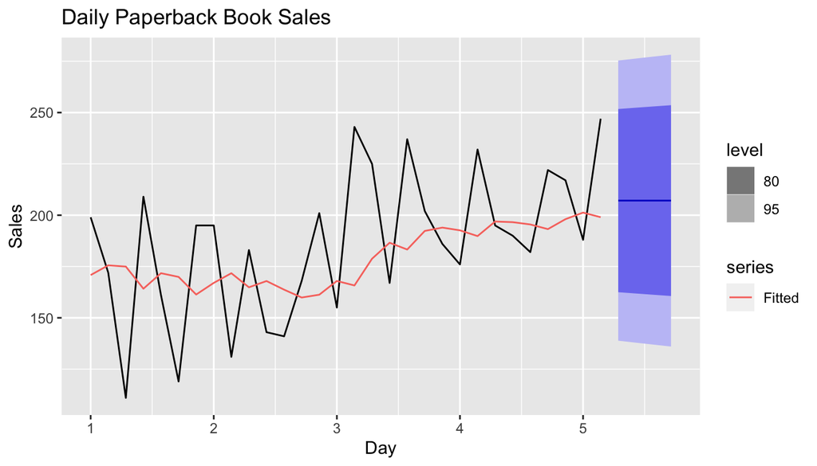

```r
autoplot(sesPaperback, main = "Daily Paperback Book Sales") +
  autolayer(sesPaperback$fitted, series="Fitted") +
  ylab("Sales") + xlab("Day")
```

```r
sesHardcover <- ses(hardcover, h=4)
summary(sesHardcover)
```

```
##
## Forecast method: Simple exponential smoothing
##
## Model Information:
## Simple exponential smoothing
##
## Call:
##  ses(y = hardcover, h = 4)
##
##   Smoothing parameters:
##     alpha = 0.3283
##
##   Initial states:
##     l = 149.2861
##
##   sigma:  33.0517
##
##      AIC     AICc      BIC
## 315.8506 316.7737 320.0542
##
## Error measures:
##                    ME     RMSE      MAE      MPE     MAPE      MASE       ACF1
## Training set 9.166735 31.93101 26.77319 2.636189 13.39487 0.6997539 -0.1417763
##
## Forecasts:
##          Point Forecast    Lo 80    Hi 80    Lo 95    Hi 95
## 5.285714       239.5601 197.2026 281.9176 174.7799 304.3403
## 5.428571       239.5601 194.9788 284.1414 171.3788 307.7414
## 5.571429       239.5601 192.8607 286.2595 168.1396 310.9806
## 5.714286       239.5601 190.8347 288.2855 165.0410 314.0792
```

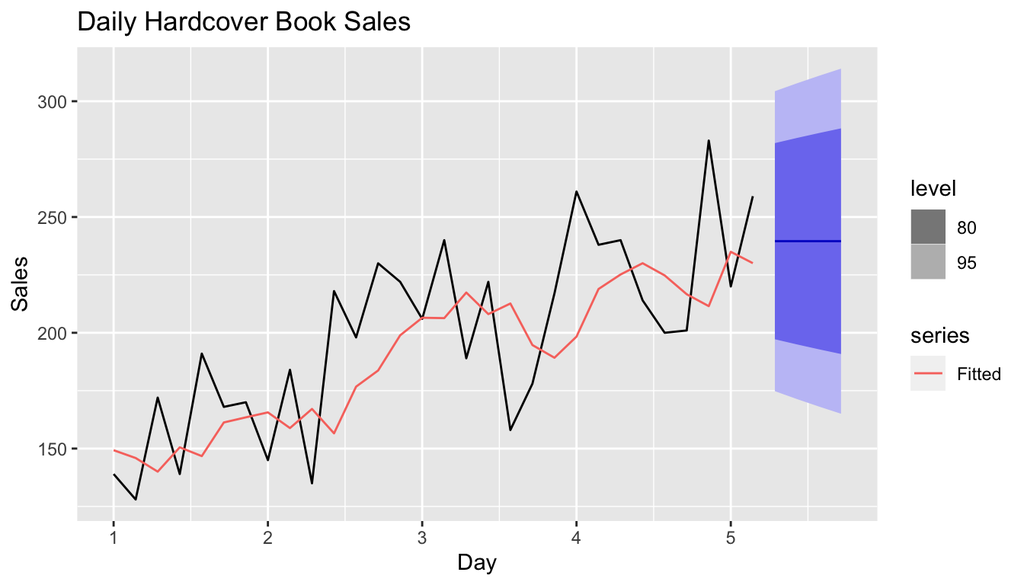

```r
autoplot(sesHardcover, main = "Daily Hardcover Book Sales") +
  autolayer(sesHardcover$fitted, series="Fitted") +
  ylab("Sales") + xlab("Day")
```

### c. Compute the RMSE values for the training data in each case.

```r
kable(round(accuracy(sesPaperback),2)) %>%
  kable_styling(bootstrap_options = c("striped", "hover", "condensed"))
```

|  | ME | RMSE | MAE | MPE | MAPE | MASE | ACF1 |
| --- | --- | --- | --- | --- | --- | --- | --- |
| Training set | 7.18 | 33.64 | 27.84 | 0.47 | 15.58 | 0.76 | -0.21 |

```r
kable(round(accuracy(sesHardcover),2)) %>%
  kable_styling(bootstrap_options = c("striped", "hover", "condensed"))
```

|  | ME | RMSE | MAE | MPE | MAPE | MASE | ACF1 |
| --- | --- | --- | --- | --- | --- | --- | --- |
| Training set | 9.17 | 31.93 | 26.77 | 2.64 | 13.39 | 0.7 | -0.14 |

```r
ses_PB_RMSE <- round(accuracy(sesPaperback)[,"RMSE"],2)
ses_HC_RMSE <- round(accuracy(sesHardcover)[,"RMSE"],2)
```

## Exercise 7.6

We will continue with the daily sales of paperback and hardcover books in data set `books.`

### a. Apply Holt’s linear method to the `paperback` and `hardback` series and compute four-day forecasts in each case.

```r
holtPaperback <- holt(paperback, h=4)
summary(holtPaperback)
```

```
##
## Forecast method: Holt's method
##
## Model Information:
## Holt's method
##
## Call:
##  holt(y = paperback, h = 4)
##
##   Smoothing parameters:
##     alpha = 1e-04
##     beta  = 1e-04
##
##   Initial states:
##     l = 170.699
##     b = 1.2621
##
##   sigma:  33.4464
##
##      AIC     AICc      BIC
## 318.3396 320.8396 325.3456
##
## Error measures:
##                     ME     RMSE      MAE       MPE     MAPE      MASE
## Training set -3.717178 31.13692 26.18083 -5.508526 15.58354 0.7177104
##                    ACF1
## Training set -0.1750792
##
## Forecasts:
##          Point Forecast    Lo 80    Hi 80    Lo 95    Hi 95
## 5.285714       209.4668 166.6035 252.3301 143.9130 275.0205
## 5.428571       210.7177 167.8544 253.5811 145.1640 276.2715
## 5.571429       211.9687 169.1054 254.8320 146.4149 277.5225
## 5.714286       213.2197 170.3564 256.0830 147.6659 278.7735
```

```r
holtHardcover <- holt(hardcover, h=4)
summary(holtHardcover)
```

```
##
## Forecast method: Holt's method
##
## Model Information:
## Holt's method
##
## Call:
##  holt(y = hardcover, h = 4)
##
##   Smoothing parameters:
##     alpha = 1e-04
##     beta  = 1e-04
##
##   Initial states:
##     l = 147.7935
##     b = 3.303
##
##   sigma:  29.2106
##
##      AIC     AICc      BIC
## 310.2148 312.7148 317.2208
##
## Error measures:
##                      ME     RMSE      MAE       MPE    MAPE      MASE
## Training set -0.1357882 27.19358 23.15557 -2.114792 12.1626 0.6052024
##                     ACF1
## Training set -0.03245186
##
## Forecasts:
##          Point Forecast    Lo 80    Hi 80    Lo 95    Hi 95
## 5.285714       250.1739 212.7390 287.6087 192.9222 307.4256
## 5.428571       253.4765 216.0416 290.9113 196.2248 310.7282
## 5.571429       256.7791 219.3442 294.2140 199.5274 314.0308
## 5.714286       260.0817 222.6468 297.5166 202.8300 317.3334
```

### b. Compare the RMSE measures of Holt’s method for the two series to those of simple exponential smoothing in the previous question. (Remember that Holt’s method is using one more parameter than SES.) Discuss the merits of the two forecasting methods for these data sets.

```r
kable(round(accuracy(holtPaperback),2)) %>%
  kable_styling(bootstrap_options = c("striped", "hover", "condensed"))
```

|  | ME | RMSE | MAE | MPE | MAPE | MASE | ACF1 |
| --- | --- | --- | --- | --- | --- | --- | --- |
| Training set | -3.72 | 31.14 | 26.18 | -5.51 | 15.58 | 0.72 | -0.18 |

```r
kable(round(accuracy(holtHardcover),2)) %>%
  kable_styling(bootstrap_options = c("striped", "hover", "condensed"))
```

|  | ME | RMSE | MAE | MPE | MAPE | MASE | ACF1 |
| --- | --- | --- | --- | --- | --- | --- | --- |
| Training set | -0.14 | 27.19 | 23.16 | -2.11 | 12.16 | 0.61 | -0.03 |

```r
holt_PB_RMSE <- round(accuracy(holtPaperback)[,"RMSE"],2)
holt_HC_RMSE <- round(accuracy(holtHardcover)[,"RMSE"],2)
```

The RMSE for the paperback book sales data using simple exponential smoothing is 33.64 vs 31.14 when using Holt’s method, which is a reduction of 2.5. The RMSE for the hardcover book sales data using simple exponential smoothing is 31.93 vs 27.19 when using Holt’s method, which is a reduction of 4.74. Holt’s method is a better predictor for the books time series since there does seem to be an upward trend in both paperback and hardcover book sales.

### c. Compare the forecasts for the two series using both methods. Which do you think is best?

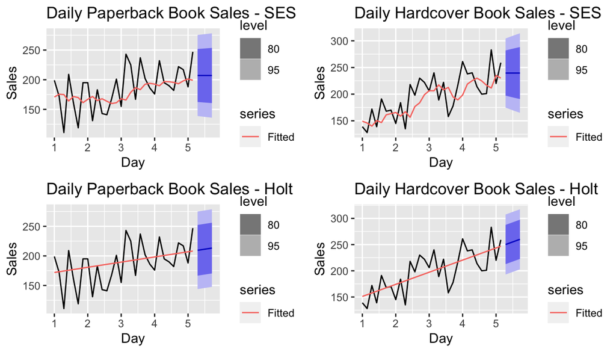

```r
p1 <- autoplot(sesPaperback, main = "Daily Paperback Book Sales - SES") +
  autolayer(sesPaperback$fitted, series="Fitted") +
  ylab("Sales") + xlab("Day")

p2 <- autoplot(sesHardcover, main = "Daily Hardcover Book Sales - SES") +
  autolayer(sesHardcover$fitted, series="Fitted") +
  ylab("Sales") + xlab("Day")

p3 <- autoplot(holtPaperback, main = "Daily Paperback Book Sales - Holt") +
  autolayer(holtPaperback$fitted, series="Fitted") +
  ylab("Sales") + xlab("Day")

p4 <- autoplot(holtHardcover, main = "Daily Hardcover Book Sales - Holt") +
  autolayer(holtHardcover$fitted, series="Fitted") +
  ylab("Sales") + xlab("Day")

grid.arrange(p1, p2, p3, p4, nrow = 2)
```

Since both methods result in a straight line forecast and do not take seasonality into account, the Holt method that includes the trend upward is a better forecaster than simple exponential smoothing.

### d. Calculate a 95% prediction interval for the first forecast for each series, using the RMSE values and assuming normal errors. Compare your intervals with those produced using `ses` and `holt`.

#### Manually Calculated Confidence Intervals

```r
conf_int <- function(fc, n){
  sd <- accuracy(fc)[,"RMSE"]
  c(fc$mean[n] - 1.96 * sd, fc$mean[n] + 1.96 * sd)
  }

ses_pb_conf_int <- conf_int(sesPaperback, 1)
ses_hc_conf_int <- conf_int(sesHardcover, 1)
holt_pb_conf_int <- conf_int(holtPaperback, 1)
holt_hc_conf_int <- conf_int(holtHardcover, 1)

manual_calc <- data.frame(ses_pb_conf_int, ses_hc_conf_int, holt_pb_conf_int, holt_hc_conf_int, row.names = c("lower", "upper"))
kable(manual_calc) %>%
  kable_styling(bootstrap_options = c("striped", "hover", "condensed"))
```

|  | ses_pb_conf_int | ses_hc_conf_int | holt_pb_conf_int | holt_hc_conf_int |
| --- | --- | --- | --- | --- |
| lower | 141.1798 | 176.9753 | 148.4384 | 196.8745 |
| upper | 273.0395 | 302.1449 | 270.4951 | 303.4733 |

#### R-Calculated Confidence Intervals

```r
conf_int <- function(fc, n){
  c(fc$lower[,"95%"][1], fc$upper[,"95%"][1])
  }

ses_pb_conf_int_r <- conf_int(sesPaperback, 1)
ses_hc_conf_int_r <- conf_int(sesHardcover, 1)
holt_pb_conf_int_r <- conf_int(holtPaperback, 1)
holt_hc_conf_int_r <- conf_int(holtHardcover, 1)

r_calc <- data.frame(ses_pb_conf_int_r, ses_hc_conf_int_r, holt_pb_conf_int_r, holt_hc_conf_int_r, row.names = c("lower", "upper"))
kable(r_calc) %>%
  kable_styling(bootstrap_options = c("striped", "hover", "condensed"))
```

|  | ses_pb_conf_int_r | ses_hc_conf_int_r | holt_pb_conf_int_r | holt_hc_conf_int_r |
| --- | --- | --- | --- | --- |
| lower | 138.8670 | 174.7799 | 143.9130 | 192.9222 |
| upper | 275.3523 | 304.3403 | 275.0205 | 307.4256 |

#### Differences

```r
r_calc - manual_calc
```

|  | ses_pb_conf_int_r | ses_hc_conf_int_r | holt_pb_conf_int_r | holt_hc_conf_int_r |
| --- | --- | --- | --- | --- |
| lower | -2.312775 | -2.195432 | -4.525411 | -3.952289 |
| upper | 2.312775 | 2.195432 | 4.525411 | 3.952289 |

Once again the confidence intervals that were manually calculated are just a little narrower than the ones calculates by the `ses` and `holt` functions in R.

## Exercise 7.7

For this exercise use data set `eggs`, the price of a dozen eggs in the United States from 1900–1993. Experiment with the various options in the `holt()` function to see how much the forecasts change with damped trend, or with a Box-Cox transformation. Try to develop an intuition of what each argument is doing to the forecasts.

[Hint: use `h=100` when calling `holt()` so you can clearly see the differences between the various options when plotting the forecasts.]

Which model gives the best RMSE?

```r
eggs <- fma::eggs
fc1eggs <- holt(eggs, h=100)
fc1eggs$model
```

```
## Holt's method
##
## Call:
##  holt(y = eggs, h = 100)
##
##   Smoothing parameters:
##     alpha = 0.8124
##     beta  = 1e-04
##
##   Initial states:
##     l = 314.7232
##     b = -2.7222
##
##   sigma:  27.1665
##
##      AIC     AICc      BIC
## 1053.755 1054.437 1066.472
```

```r
kable(accuracy(fc1eggs)) %>%
  kable_styling(bootstrap_options = c("striped", "hover", "condensed"))
```

|  | ME | RMSE | MAE | MPE | MAPE | MASE | ACF1 |
| --- | --- | --- | --- | --- | --- | --- | --- |
| Training set | 0.0449909 | 26.58219 | 19.18491 | -1.142201 | 9.653791 | 0.9463626 | 0.013482 |

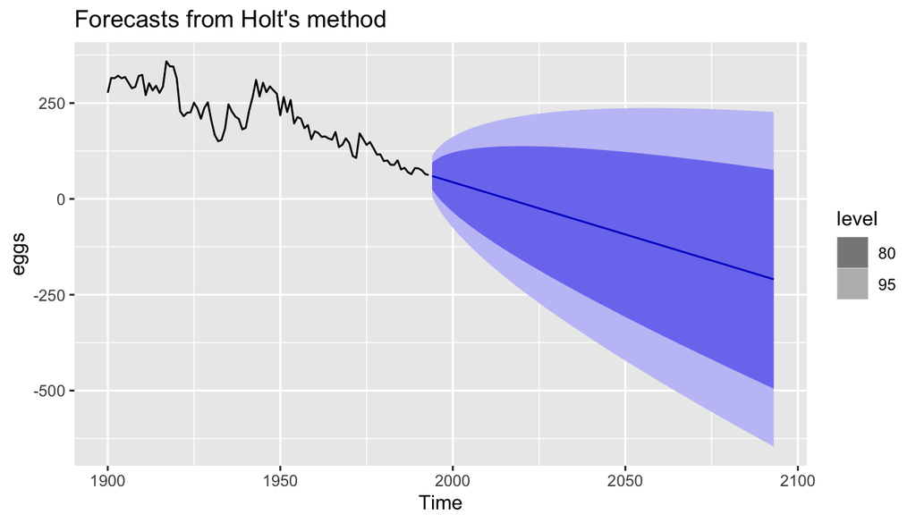

```r
autoplot(fc1eggs)
```

```r
eggs <- fma::eggs
fc2eggs <- holt(eggs, damped=TRUE, phi=0.9, h=100)
fc2eggs$model
```

```
## Damped Holt's method
##
## Call:
##  holt(y = eggs, h = 100, damped = TRUE, phi = 0.9)
##
##   Smoothing parameters:
##     alpha = 0.8464
##     beta  = 1e-04
##     phi   = 0.9
##
##   Initial states:
##     l = 297.4547
##     b = -3.1897
##
##   sigma:  27.3608
##
##      AIC     AICc      BIC
## 1054.045 1054.727 1066.761
```

```r
kable(accuracy(fc2eggs)) %>%
  kable_styling(bootstrap_options = c("striped", "hover", "condensed"))
```

|  | ME | RMSE | MAE | MPE | MAPE | MASE | ACF1 |
| --- | --- | --- | --- | --- | --- | --- | --- |
| Training set | -2.584906 | 26.62317 | 19.53231 | -2.832104 | 10.10674 | 0.9634993 | -0.0050198 |

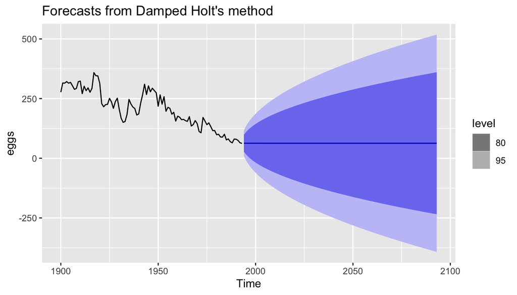

```r
autoplot(fc2eggs)
```

```r
eggs <- fma::eggs
fc3eggs <- holt(eggs, lambda="auto", h=100)
fc3eggs$model
```

```
## Holt's method
##
## Call:
##  holt(y = eggs, h = 100, lambda = "auto")
##
##   Box-Cox transformation: lambda= 0.3956
##
##   Smoothing parameters:
##     alpha = 0.809
##     beta  = 1e-04
##
##   Initial states:
##     l = 21.0322
##     b = -0.1144
##
##   sigma:  1.0549
##
##      AIC     AICc      BIC
## 443.0310 443.7128 455.7475
```

```r
kable(accuracy(fc3eggs)) %>%
  kable_styling(bootstrap_options = c("striped", "hover", "condensed"))
```

|  | ME | RMSE | MAE | MPE | MAPE | MASE | ACF1 |
| --- | --- | --- | --- | --- | --- | --- | --- |
| Training set | 0.7736844 | 26.39376 | 18.96387 | -1.072416 | 9.620095 | 0.9354593 | 0.0388715 |

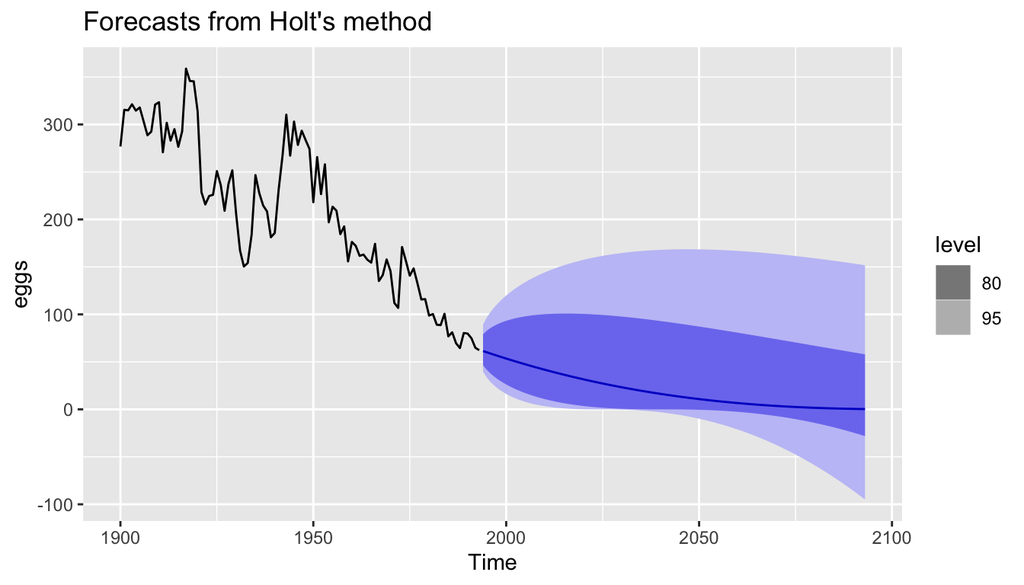

```r
autoplot(fc3eggs)
```

```r
eggs <- fma::eggs
fc4eggs <- holt(eggs, damped=TRUE, phi=0.9, lambda="auto", h=100)
fc4eggs$model
```

```
## Damped Holt's method
##
## Call:
##  holt(y = eggs, h = 100, damped = TRUE, phi = 0.9, lambda = "auto")
##
##   Box-Cox transformation: lambda= 0.3956
##
##   Smoothing parameters:
##     alpha = 0.8468
##     beta  = 1e-04
##     phi   = 0.9
##
##   Initial states:
##     l = 20.873
##     b = 0.125
##
##   sigma:  1.0694
##
##      AIC     AICc      BIC
## 444.5430 445.2248 457.2595
```

```r
kable(accuracy(fc4eggs)) %>%
  kable_styling(bootstrap_options = c("striped", "hover", "condensed"))
```

|  | ME | RMSE | MAE | MPE | MAPE | MASE | ACF1 |
| --- | --- | --- | --- | --- | --- | --- | --- |
| Training set | -2.979642 | 26.54716 | 19.2466 | -2.932978 | 10.00465 | 0.9494056 | -0.0019255 |

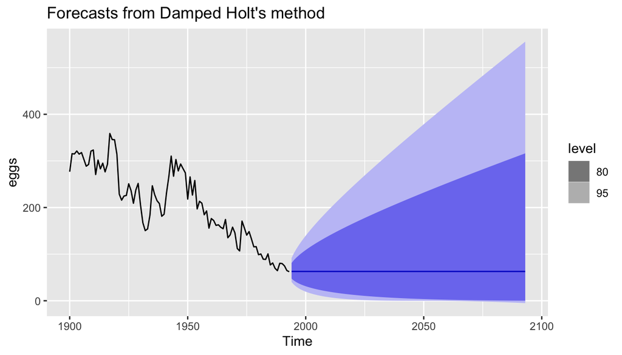

```r
autoplot(fc4eggs)
```

```r
fc1_RMSE <- accuracy(fc1eggs)[,"RMSE"]
fc2_RMSE <- accuracy(fc2eggs)[,"RMSE"]
fc3_RMSE <- accuracy(fc3eggs)[,"RMSE"]
fc4_RMSE <- accuracy(fc4eggs)[,"RMSE"]

c(fc1_RMSE, fc2_RMSE, fc3_RMSE, fc4_RMSE)
```

```
## [1] 26.58219 26.62317 26.39376 26.54715
```

The Holt model with box-cox transformation and no dampening seems to produce the best forecasts and also has the best (lowest) RMSE. The first model without any dampening or box-cox transformation drops the price into the negative which is impossible. The dampened but untransformed data levels out at it’s current price and stays there forever. The box-cox transformed data slopes down at first but slowly curves upwards so that it levels out at about 0. It also has the narrowest confidence intervals. The box-cox transformed and dampened forecast has confidence intervals that almost never go into the negatives, so in that way it may be the best model, but the price forecast levels out at the current price without change and the upper confidence limit is extremely wide.

## Exercise 7.8

Recall your retail time series data (from Exercise 3 in Section 2.10).

### a. Why is multiplicative seasonality necessary for this series?

### b. Apply Holt-Winters’ multiplicative method to the data. Experiment with making the trend damped.

### c. Compare the RMSE of the one-step forecasts from the two methods. Which do you prefer?

### d. Check that the residuals from the best method look like white noise.

### e. Now find the test set RMSE, while training the model to the end of 2010. Can you beat the seasonal naïve approach from Exercise 8 in Section 3.7?

## Exercise 7.9

For the same retail data, try an STL decomposition applied to the Box-Cox transformed series, followed by ETS on the seasonally adjusted data. How does that compare with your best previous forecasts on the test set?